# R俱乐部

红色点所在的区间即为置信区间

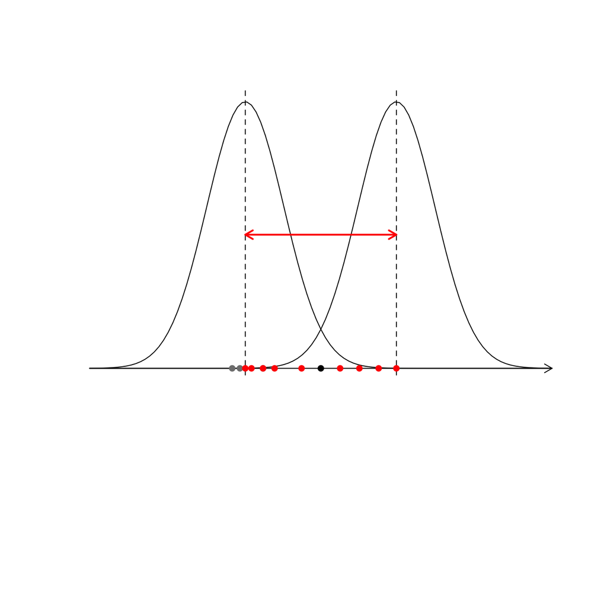

#置信区间的计算方法（Pr=1-α）

正如上面的图所表示
>假说如果正好选在置信区间的左端的情况下，数据正好在下侧的（1-α/2）100%。或者说上侧p值即为α/2。

>假说如果正好选在置信区间的右端的情况下，数据正好在上侧的α/2*100%。或者说上侧p值即为1-α/2。

#自由度为n-1的t分布

`$$t=\frac{\bar{X}-\mu}{\sqrt{S^{2}/n}}$$`

假设如果在以下范围内，虚无假说则不舍弃↓
`$$Prob\left\{
t_{n-1}^{\alpha/2}\leqq\frac{\bar{X}-\mu_{0}}{\sqrt{S^{2}/n}}\leqq  t_{n-1}^{1-\alpha/2}\right\} =1-\alpha$$`
→
`$$Prob\left\{ \bar{X}-t_{n-1}^{1-\alpha/2}\sqrt{\frac{S^{2}}{n}}\leqq\mu_{0}\leqq\bar{X}-t_{n-1}^{\alpha/2}\sqrt{\frac{S^{2}}{n}}\right\} =1-\alpha$$`
→置信区间
`$$\left[\bar{X}-t_{n-1}^{1-\alpha/2}\sqrt{\frac{S^{2}}{n}},\bar{X}-t_{n-1}^{\alpha/2}\sqrt{\frac{S^{2}}{n}}\right]$$`

# 问题练习

1.不要使用t.test（），求出95%的置信区间。

```r
w <- c(101.1, 103.2, 102.1, 99.2, 100.5, 101.3,
       99.7, 100.5, 98.9, 101.4)
```

# 答案

```r
mean(w) - sqrt(var(w) / length(w)) * qt(0.975, length(w) - 1)
```

```
## [1] 99.8449
```

```r
mean(w) - sqrt(var(w) / length(w)) * qt(0.025, length(w) - 1)
```

```
## [1] 101.7351
```

##使用t.test

```r
t.test(w)
```

```
##
## 	One Sample t-test
##
## data:  w
## t = 241.25, df = 9, p-value < 2.2e-16
## alternative hypothesis: true mean is not equal to 0
## 95 percent confidence interval:
##   99.8449 101.7351
## sample estimates:
## mean of x
##    100.79
```

#总结

- 置信区间：找寻的是不要舍弃虚无假说的范围

置信区间的下限和上限的范围正好是（1-显著性水平）

- 也就是说，p值正好5%的俩端的俩个点正好是置信区间的俩端。

## 拓展

- F-检验：用来分析用了超过一个参数的统计模型，以判断该模型中的全部或一部分参数是否适合用来估计母体。

- 卡方检验：统计样本的实际观测值与理论推断值之间的偏离程度

- fisher.test:检验俩个二进制变量之间是否是独立的（例如抽烟与肺癌之间的关系）
。。。。

# 练习

## 例１

右の表１は定期健診での最高血圧の一覧表であるものとする．Ａ欄は昨年の定期検査時の最高血圧，Ｂ欄は今年の定期検査時の最高血圧とする．
　この一覧表では12人の被験者について，昨年の定期検査時と今年の定期検査時の最高血圧が対のデータとなっている．
　これらのデータからＡ欄の値とＢ欄の値を比較すると，Ａ欄のデータとＢ欄のデータは同一被験者のデータであるので，昨年と今年という条件だけが異なることになり，昨年の最高血圧と今年の最高血圧に有意差があるかどうか調べることができる．

|   A|   B|
|---:|---:|
| 109| 105|
| 115| 100|
| 107| 118|
| 124| 122|
| 123| 122|
| 112| 125|
| 128| 101|
| 119| 128|
| 121| 104|
| 124| 107|
| 123| 103|
| 123| 128|

```r
A=c(109,115,107,124,123,112,128,119,121,124,123,123)
B=c(105,100,118,122,122,125,101,128,104,107,103,128)
test=B-A
t.test(test)
```

```
##
## 	One Sample t-test
##
## data:  test
## t = -1.3926, df = 11, p-value = 0.1912
## alternative hypothesis: true mean is not equal to 0
## 95 percent confidence interval:
##  -13.97738   3.14405
## sample estimates:
## mean of x
## -5.416667
```

```r
t.test(A,B,paired = TRUE)
```

```
##
## 	Paired t-test
##
## data:  A and B
## t = 1.3926, df = 11, p-value = 0.1912
## alternative hypothesis: true difference in means is not equal to 0
## 95 percent confidence interval:
##  -3.14405 13.97738
## sample estimates:
## mean of the differences
##                5.416667
```